# Human Activity Recognition: Analysis with Machine Learning

Taras Poltorak

08/10/2019

## Background

Using devices such as Jawbone Up, Nike FuelBand, and Fitbit it is now possible to collect a large amount of data about personal activity relatively inexpensively. These type of devices are part of the quantified self movement – a group of enthusiasts who take measurements about themselves regularly to improve their health, to find patterns in their behavior, or because they are tech geeks. One thing that people regularly do is quantify how much of a particular activity they do, but they rarely quantify how well they do it. In this project, the goal will be to use data from accelerometers on the belt, forearm, arm, and dumbell of 6 participants. They were asked to perform barbell lifts correctly and incorrectly in 5 different ways. More information is available from the website here: http://web.archive.org/web/20161224072740/http:/groupware.les.inf.puc-rio.br/har (see the section on the Weight Lifting Exercise Dataset).

## Getting the data

We’ll check if the data already exists locally and, if not, we download it.

```r
# Get the training data

train_fileurl <- 'https://d396qusza40orc.cloudfront.net/predmachlearn/pml-training.csv'

if (!file.exists('pml-training.csv')){
  download.file(train_fileurl,'./pml_training.csv')

}

train_df <- read.csv("pml_training.csv", na.strings=c("NA","#DIV/0!", ""))

# Get the test data

test_fileurl <- 'https://d396qusza40orc.cloudfront.net/predmachlearn/pml-testing.csv'

if (!file.exists('pml-testing.csv')){
  download.file(train_fileurl,'./pml_testing.csv')

}

test_df <- read.csv("pml_testing.csv", na.strings=c("NA","#DIV/0!", ""))
```

## EDA and Data Cleaning

```r
glimpse(train_df)
```

```
## Observations: 19,622
## Variables: 160
## $ X                        <int> 1, 2, 3, 4, 5, 6, 7, 8, 9, 10, 11, 12...
## $ user_name                <fct> carlitos, carlitos, carlitos, carlito...
## $ raw_timestamp_part_1     <int> 1323084231, 1323084231, 1323084231, 1...
## $ raw_timestamp_part_2     <int> 788290, 808298, 820366, 120339, 19632...
## $ cvtd_timestamp           <fct> 05/12/2011 11:23, 05/12/2011 11:23, 0...
## $ new_window               <fct> no, no, no, no, no, no, no, no, no, n...
## $ num_window               <int> 11, 11, 11, 12, 12, 12, 12, 12, 12, 1...
## $ roll_belt                <dbl> 1.41, 1.41, 1.42, 1.48, 1.48, 1.45, 1...
## $ pitch_belt               <dbl> 8.07, 8.07, 8.07, 8.05, 8.07, 8.06, 8...
## $ yaw_belt                 <dbl> -94.4, -94.4, -94.4, -94.4, -94.4, -9...
## $ total_accel_belt         <int> 3, 3, 3, 3, 3, 3, 3, 3, 3, 3, 3, 3, 3...
## $ kurtosis_roll_belt       <dbl> NA, NA, NA, NA, NA, NA, NA, NA, NA, N...
## $ kurtosis_picth_belt      <dbl> NA, NA, NA, NA, NA, NA, NA, NA, NA, N...
```

[output cut: 147 more lines]

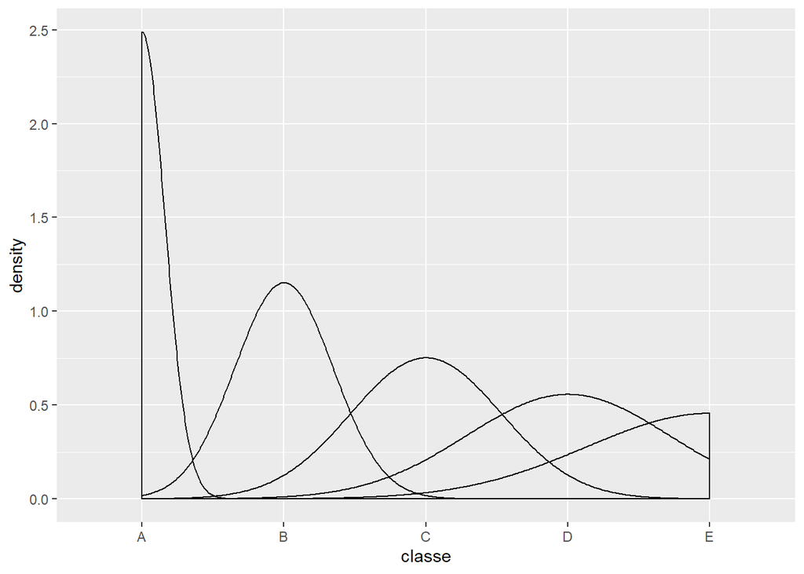

```r
ggplot(train_df, aes(x = classe)) + geom_density()
```

```r
train_df <- train_df[,colSums(is.na(train_df)) == 0]
train_df <- train_df[,-c(1:7)]

test_df <- test_df[,colSums(is.na(test_df)) == 0]
test_df <- test_df[,-c(1:7)]

near_zero <- nearZeroVar(train_df, saveMetrics = TRUE)

train_df <- train_df[, !near_zero$nzv]
test_df <- test_df[, !near_zero$nzv]
```

## Pre-processing

Now we are going to partition the **train_df** into the training and validation parts.

```r
test_split <- train_df %>%
    initial_split(prop = 0.7, strata = "classe")

data_training <- training(test_split)
data_testing <- testing(test_split)
```

## Now let’s fit some models.

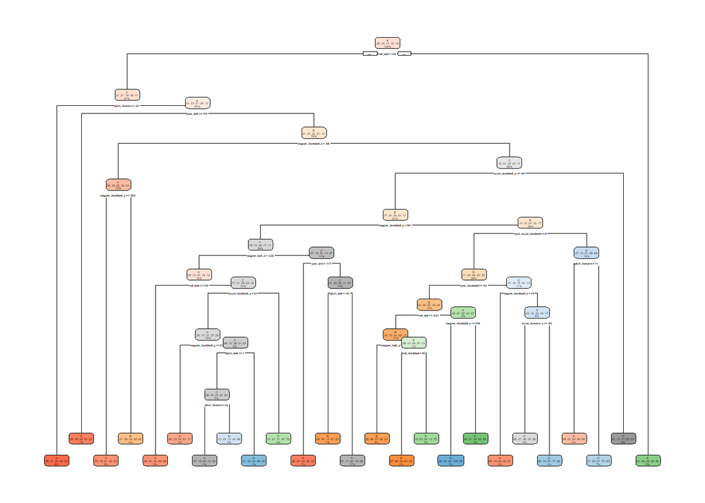

```r
# Decision Tree

fit_decTree <- rpart(classe ~ .,
                     data = data_training,
                     method = "class")

rpart.plot(fit_decTree)
```

```r
# Random Forest

fit_RF <- train(classe ~ .,
                 data = data_training,
                 method = "rf",
                 trControl = trainControl(method = "cv", 5),
                 ntree = 250)
```

Let’s have a look at the results

```r
pred_decTree <- predict(fit_decTree, data_testing, type = "class")
confusionMatrix(pred_decTree, data_testing$classe)
```

```
## Confusion Matrix and Statistics
##
##           Reference
## Prediction    A    B    C    D    E
##          A 1477  196   17   50   61
##          B    5  668   58   67   11
##          C   54  187  888  177  171
##          D   93   86   39  634   60
##          E   45    2   24   36  779
##
## Overall Statistics
##
##                Accuracy : 0.7555
##                  95% CI : (0.7443, 0.7664)
##     No Information Rate : 0.2845
##     P-Value [Acc > NIR] : < 2.2e-16
##
##                   Kappa : 0.6903
##
##  Mcnemar's Test P-Value : < 2.2e-16
##
## Statistics by Class:
##
##                      Class: A Class: B Class: C Class: D Class: E
## Sensitivity            0.8823   0.5865   0.8655   0.6577   0.7200
## Specificity            0.9231   0.9703   0.8788   0.9435   0.9777
## Pos Pred Value         0.8201   0.8257   0.6012   0.6952   0.8792
## Neg Pred Value         0.9518   0.9072   0.9687   0.9336   0.9394
## Prevalence             0.2845   0.1935   0.1743   0.1638   0.1839
## Detection Rate         0.2510   0.1135   0.1509   0.1077   0.1324
## Detection Prevalence   0.3060   0.1375   0.2510   0.1550   0.1506
## Balanced Accuracy      0.9027   0.7784   0.8721   0.8006   0.8488
```

```r
pred_rf <- predict(fit_RF, data_testing, type = "raw")
confusionMatrix(pred_rf, data_testing$classe)
```

```
## Confusion Matrix and Statistics
##
##           Reference
## Prediction    A    B    C    D    E
##          A 1670    9    0    0    0
##          B    1 1130    0    0    0
##          C    3    0 1021    9    1
##          D    0    0    5  954    9
##          E    0    0    0    1 1072
##
## Overall Statistics
##
##                Accuracy : 0.9935
##                  95% CI : (0.9911, 0.9954)
##     No Information Rate : 0.2845
##     P-Value [Acc > NIR] : < 2.2e-16
##
##                   Kappa : 0.9918
##
##  Mcnemar's Test P-Value : NA
##
## Statistics by Class:
##
##                      Class: A Class: B Class: C Class: D Class: E
## Sensitivity            0.9976   0.9921   0.9951   0.9896   0.9908
## Specificity            0.9979   0.9998   0.9973   0.9972   0.9998
## Pos Pred Value         0.9946   0.9991   0.9874   0.9855   0.9991
## Neg Pred Value         0.9990   0.9981   0.9990   0.9980   0.9979
## Prevalence             0.2845   0.1935   0.1743   0.1638   0.1839
## Detection Rate         0.2838   0.1920   0.1735   0.1621   0.1822
## Detection Prevalence   0.2853   0.1922   0.1757   0.1645   0.1823
## Balanced Accuracy      0.9977   0.9959   0.9962   0.9934   0.9953
```

```r
fit_RF$finalModel
```

```
##
## Call:
##  randomForest(x = x, y = y, ntree = 250, mtry = param$mtry)
##                Type of random forest: classification
##                      Number of trees: 250
## No. of variables tried at each split: 27
##
##         OOB estimate of  error rate: 0.68%
## Confusion matrix:
##      A    B    C    D    E class.error
## A 3900    4    1    0    1 0.001536098
## B   19 2627   11    1    0 0.011662904
## C    0   11 2376    9    0 0.008347245
## D    0    0   23 2228    1 0.010657194
## E    0    1    5    7 2512 0.005148515
```

As we can see, the out-of-sample error is extremely small.

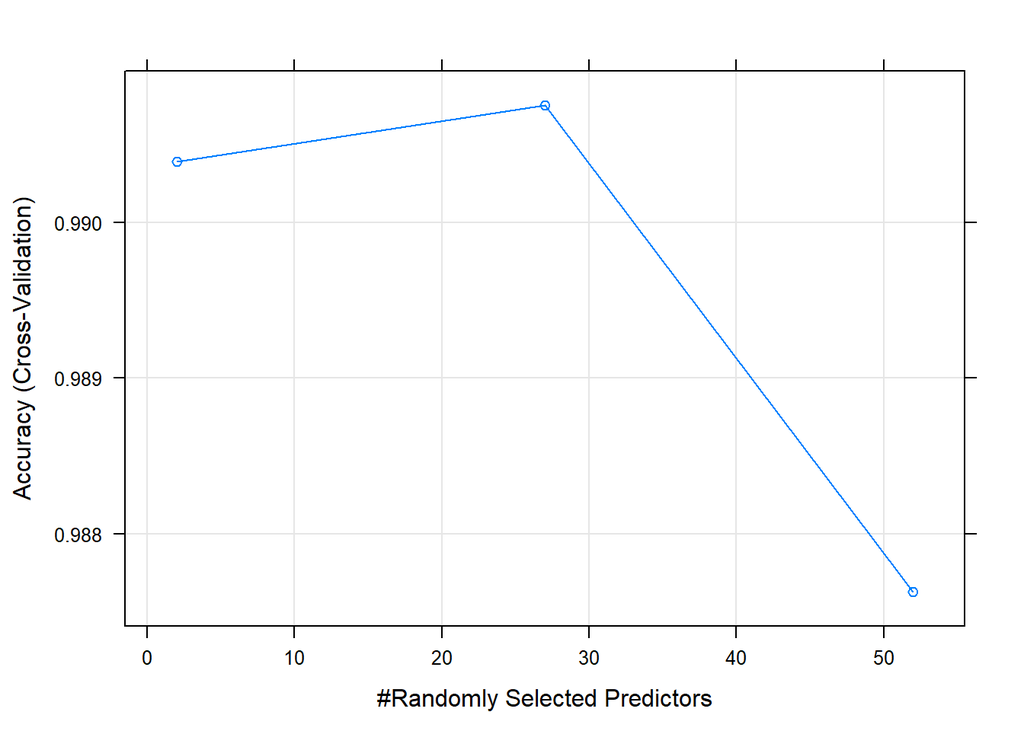

```r
plot(fit_RF)
```